# Predviđanje ishoda teniskih mečeva

Ivona Matijević, Dunja Prokić, Jovan Samardžić, Jana Stojanović

Matematički fakultet, Univerzitet u Beogradu

Maj 2023.

## 1. Uvod

**Tenis** je jedan od najpopularnijih sportova današnjice, koji se igra, trenira i prati širom sveta. Sa popularnošću nekog sporta, raste i značaj uspešnog predviđanja njegovih rezultata:

- Kladionicama je veoma značajno da što preciznije predvide rezultat, kako ne bi doživljavale velike gubitke
- Sa druge strane, ukoliko je pojedinac sposoban da uspešno (uspešnije od kladionice) predvidi ishod meča, on je u mogućnosti da ostvari dobitak

Tensiki turniri koji se odigraju tokom godine utiču na takozvani rang igrača. Naime, što više bodova igrač sakupi, to je bolje plasiran na ATP listi, što mu, na narednim turnirima, garantuje pre svega učešće, a onda i *"lakše"* protivnike u ranijim fazama turnira. Reč *lakše* je pod znacima navoda iz sledećeg razloga: kada bi se zaista, sa stoprocentnom sigurnošću, znalo ko je lakši, a ko teži protivnik, problem predviđanja ishoda mečeva ne bi postojao. Koristili bismo isključivo ATP listu kao pokazatelj, predvideli pobedu bolje plasiranog igrača, i završili posao.

Naravno, ispostavlja se da ova metoda ne daje toliko dobre rezultate. Empirijski ćemo kasnije pokazati da bi ova metoda bila uspešna samo u oko **64% slučajeva**. Razlog za ovo je jasan: meč se ne dobija u svlačionici, niti na papiru, na kome je neko jači protivnik, već se dobija na terenu, tako što se u igri snage, uma i nerava nadmudri osoba koja se nalazi sa druge strane mreže.

Razmišljajući na ovaj način, **Ajay Krishna Amudan**, na čiji ćemo se rad [*"Tennis Match Prediction using Machine Learning"*](https://cs229.stanford.edu/proj2019aut/data/assignment_308832_raw/26647696.pdf) pozivati, odlučio je da, koristeći dostupne podatke o mečevima u prošlosti, napravi model koji će pogađati pobednika meča sa preciznošću većom od 64%, koju dostižemo prethodno opisanim postupkom.

Cilj našeg rada jeste da, uz detaljnu analizu pomenutog rada, predložimo metode kojima bi predikcija ishoda mečeva mogla dodatno da se unapredi.

### Turniri i bodovanje

Kao što je pomenuto u uvodu, rezultati koje igrač postigne na turniru utiču na broj njegovih bodova na ATP listi. Pre svega, važno je napomenuti da nisu svi turniri podjednako važni i da ne donose svi jednak broj poena. Iz tog razloga, podaci koje koristimo inicijalno su podeljeni u 2 kategorije: ATP turniri i čelendžeri.

U kategoriju ATP turnira spadaju:

- **Grend Slem turniri**, na kojima pobednik osvaja 2000 poena
- **ATP Masters turniri**, na kojima pobednik osvaja 1000, 500 ili 250 poena, u zavisnosti od samog turnira
- **ATP kup**, na kome pobednik ne osvaja poene, ali učinak na tim mečevima svakako utiče na statistiku igrača
- **Dejvis kup**, koji je reprezentativno takmičenje, za koje se pokazalo da je veoma teško predvideti rezultate, zbog čega ga nećemo uzimati u obzir

**Čelendžeri** su turniri koji su namenjeni slabije rangiranim igračima, kako bi i oni mogli da sakupe poene i dodju do boljeg plasmana na ATP listi. U zavisnosti od samog turnira, pobednik može da osvoji 175, 125, 100, 75 ili 50 poena.

### Šta utiče na ishod meča?

Kao što smo već rekli, upoređivanjem pozicija igrača na ATP listi, odnosno njihovog broja bodova, možemo, na neki način, pretpostaviti ko je favorit u meču, ali su nam mnogi drugi prediktori veoma značajni kako bismo sa većom preciznošću mogli da iznesemo finalnu pretpostavku.

Između ostalog, postoje razičite podloge, koje odgovaraju različitim stilovima igre. Na primer, na meču dva ista igrača na šljaci, može da se desi da jedan ima veće šanse za pobedu, dok je na travi drugi igrač favorit.

Uobičajene statistike koje možemo videti na svojim ekranima kada gledamo teniski meč, kao što su asovi, duple servis greške, procenat ubačenog prvog, odnosno drugog servisa i spašene brejk lopte, očekivano su uključene u model, iz razloga što govore o kvalitetu tenisera u različitim segmentima igre.

Takođe, ako je neki igrač bio povredjen ili je u slabijoj formi, to smanjuje njegove šanse za pobedu, dok mu dobra forma omogućava da bude favorit.

Vodeći se ovakvim, zdravorazumskim razmišljanjem, Ajay je u svoj model uključio razne prediktore, i dodao neke nove, za koje postoji veoma dobro opravdanje i koji su značajno doprineli većoj preciznosti, a koje ćemo detaljno objasniti u nastavku rada.

## 2. Podaci

Podatke koje koristimo u ovom radu prikupljao je Jeff Sackman. Na njegovoj GitHub stranici nalazi se repozitorijum sa podacima o svim ATP mečevima od 1968 pa do danas. Ono što izdvaja ovu bazu od ostalih jeste to što je uvek ažurna (svake nedelje se dodaju svi odigrani mečevi) i to što su svi podaci javno dostupni, tj. besplatni su za preuzimanje. Svi podaci se mogu naći na [sledećem linku.](https://github.com/JeffSackmann/tennis_atp)

Baza se sastoji iz velikog broja .csv fajlova, gde svaki fajl sadrži informacije o mečevima iz odgovarajuće godine. Takođe, u posebnim fajlovima se nalaze mečevi kvalifikacija i čelendžera, dok se odvojeno zapisuju mečevi iz glavnog dela turnira.

Struktura svih fajlova je slična. Svaki red predstavlja jedan meč, te su u njemu sadržane sve informacije o pobedniku i gubitniku meča, kao i ostale informacije o turniru na kom je odigran taj meč.

Pogledajmo kolone, tj. atribute koji se nalaze u svakom .csv fajlu:

- `tourney_id` - ID turnira, koji je zapisan u formatu GGGG_BBB (GGGG - godina, BBB - turnir)
- `tourney_name` - naziv turnira
- `surface` - podloga na kojoj se igra turnir
- `draw_size` - veličina žreba, broj igrača na turniru
- `tourney_level` - nivo turnira ('G'= grend slem, 'M' = masters, 'A' = ostali)
- `tourney_date` - datum odigravanja meča
- `match_num` - ID meča na turniru (uglavnom počevši od 1, pa rastuće)

  Nakon ovih opštih informacija o turniru, slede informacije o pobedniku meča:
- `winner_id` - ID pobednika
- `winner_seed` - broj koji predstavlja koji je nosilac bio igrač na turniru
- `winner_entry` - predstavlja način na koji se pobednik kvalifikovao na turnir *(kvalifikacije, wild card, direktno...)*
- `winner_name` - ime pobednika
- `winner_hand` - ruka kojom pobednik dominantnije igra
- `winner_ht` - visina pobednika (u cm)
- `winner_ioc` - država porekla pobednika
- `winner_age` - broj godina pobednika

  Zatim iste te informacije samo o gubitniku:
- `loser_id`, `loser_seed`, `loser_entry`, `loser_name`, `loser_hand`, `loser_ht`, `loser_ioc`, `loser_age`

  Slede detalji o samom meču. Opet, prvo idu opšte informacije:
- `score` - konačni rezultat meča
- `best_of` - broj dobijenih setova do kog se igra
- `round` - runda meča
- `minutes` - trajanje meča (u minutima)

  Zapisane su i numeričke statistike pobednika meča:
- `w_ace` - broj asova pobednika
- `w_df` - broj duplih grešaka pobednika
- `w_svpt` - broj poena u kojima je pobednik servirao
- `w_1stIn` - broj uspešnih prvih servisa pobednika
- `w_1stWon` - broj osvojenih poena pobednika na njegov prvi servis
- `w_2ndWon`- broj osvojenih poena pobednika na njegov drugi servis
- `w_SvGms` - broj gemova u kojima je pobednik servirao
- `w_bpSaved` - broj spašenih brejk lopti pobednika
- `w_bpFaced` - broj ukupnih brejk lopti gubitnika

  A onda iste te numeričke statistike, samo za gubitnika:
- `l_ace`, `l_df`, `l_svpt`, `l_1stIn`, `l_1stWon`, `l_2ndWon`, `l_SvGms`, `l_bpSaved`, `l_bpFaced`

  Na kraju, zapisana su i stanja na ATP rang listi za oba igrača:
- `winner_rank` - rang pobednika
- `winner_rank_points` - broj bodova pobednika
- `loser_rank` - rang gubitnika
- `loser_rank_points` - broj bodova gubitnika

Kako bi se model poboljšao, osim većine već pomenutih prediktora, autor pomenutog rada ih je osmislio još nekoliko. Postojalo dosta atributa koje je imalo smisla ispitivati, ali nakon dosta eksperimentisanja, autor je došao do zaključka da su sledeći atributi doneli najznačajna unapređenja u preciznosti.

- `Tournament Form` – ukupan broj pobeda/poraza na određenom turniru
- `Match based Form` - broj pobeda/poraza u poslednjih 5/10/15/25 mečeva
- `Time based Form` - broj pobeda/poraza u poslednjih 30 dana
- `Surface Level Overall Form` - ukupan broj pobeda/poraza na određenoj podlozi
- `Surface Level Match based Form` - broj pobeda/poraza igrača u poslednjih 5/10/15/25 mečeva na određenoj podlozi
- `Overall performance` - ukupan broj pobeda/poraza u karijeri
- `Overall head to head` - ukupan broj pobeda/poraza jedno protiv drugog
- `Component Opponents Win/Loss` - broj pobeda/poraza protiv zajedničkih protivnika (sa kojim su oba igrača igrala)
- `Surface level head to head` - ukupan broj pobeda/poraza jedno protiv drugog jedno protiv drugih na određenoj podlozi
- `Overall Historic Average and cumulative Match Level Statistics` - numeričke statistike
- `Player attributes` - nosilac, visina, ruka, rang, bodovi

Neke od ovih atributa ćemo posmatrati na više različitih načina. Na primer, za `Overall head to head` ćemo gledati i bukvalno koliki je odnos pobeda i poraza, ali ćemo gledati i kako se to odnosi u procentima. Konkretno, ako neka dva igrača imaju međusobni skor 5:0, verovatnije je da će taj igrač opet pobediti. Ali ako je odnos 35:30, razlika je opet 5, ali ta informacija nije toliko značajna kao u prethodnom slučaju.

## 3. Model

**Logistička regresija** je model klasifikacije. Osnovna pretpostavka sa probabilističke tačke gledišta je pretpostavka Bernulijeve raspodele zavisne promenljive Y, pri datim vrednostima atributa X (tj. uslovna raspodela). Drugim rečima, za date vrednosti atributa X, postoji parametar $\pi$ ∈ $[0,1]$ tako da važi P(Y=1 | X) = $\pi$, dok se vrednost za P(Y = 0 | X) odatle jednoznačno izračunava.

Međutim, taj parametar mora biti u intervalu $[0, 1]$ da bi verovatnoća bila ispravno definisana. **Logistička (logit) funkcija** $f(x)=\frac{e^x}{e^x+1}=\frac{1}{1+e^−x}$ je jedna, ali ne i jedina, funkcija transformacije koja slika $[-\infty,+\infty]$ u $[0, 1]$ i pritom je monotona. Znači, modelom logističke regresije opisujemo vezu između prediktora (koji mogu biti i numerički i kategoricki) i kategoričke zavisne promenljive.

U ovom slučaju, reč je o binarnoj logističkoj regresiji, tj. zavisna promenljiva će biti binarna - na osnovu nekih prediktora predviđamo da li će se nešto desiti ili ne (uspeh/neuspeh). Mi zapravo ocenjujemo verovatnoće pripadanja svakoj kategoriji za dat skup prediktora, tj. svakoj intanci dodeljujemo tzv. **skor**. Konkretno, bavićemo se ocenjivanjem verovatnoće da neki teniser pobedi/izgubi meč.

Model logističke regresije je:

$\pi=\frac{\exp(\beta_0+\beta_1X_1+…+\beta_{p−1}X_{p−1})}{1+exp(β_0+β_1X_1+…+β_{p−1}X_{p−1})}=\frac{exp(Xβ)}{1+exp(Xβ)}=\frac{1}{1+exp(-Xβ)}$

gde $\pi$ predstavlja verovatnoću da opservacija pripada kategoriji zavisne promenljive koju smo označili kao uspeh. Ovim modelom opisuje se verovatnoća događaja kao funkcija prediktora X. Pomenuli smo da je Y Bernulijeva slučajna veličina. Tačnije, smatramo da je uslovna raspodela Y<sub>i</sub> | X=x<sub>i</sub> Bernulijeva sa parametrom $\pi$.

U logističkom modelu zavisna promenljiva je logistička funkcija linearne funkcije prediktora. Odnosno linearnu funkciju prediktora možemo onda izraziti kao logaritam tzv. **kvote**: $\frac{\pi(x)}{1-\pi(x)}$ na sledeći način:

$\log(\frac{\pi(x)}{1-\pi(x)})=\beta_0+\beta_1X$

Parametri logističke regresije se ocenjuju metodom maksimalne verodostojnosti.

## 4. Implementacija

Na početku učitavamo sve potrebne biblioteke

```python
import csv
import numpy as np
from sklearn.linear_model import LogisticRegression
```

Definišemo dve pomoćne funkcije, koje ćemo koristiti kada budemo određivali mečeve koji su se igrali u poslednjih 30 dana.

- `getdays` kao ulaz uzima datum, a kao izlaz daje odgovarajući broj dana;
- `getmonth` kao ulaz uzima datum, a kao izlaz daje mesec.

```python
def getdays(date1):
    year1 = int(date1[0] + date1[1] + date1[2] + date1[3])
    month1 = int(date1[4] + date1[5])
    date1 = int(date1[6] + date1[7])

    answer = 365*year1 + 30*month1 + date1
    return answer

def getmonth(date1):
    month1 = int(date1[4] + date1[5])
    return month1
```

### Učitavanje baze

Objasnili smo da imamo veliki broj baza. Takođe, redosled, kao i sam broj kolona je različit za baze glavnih turnira i baze kvalifikacija. Potrebno je da sve baze učitamo u jedinstvenu bazu tako da imamo fiksiran redosled kolona.

Zbog toga, pravimo pomoćnu funkciju `create_add_year_matches`. Kao prvi argument, ona uzima putanju ulaznog .csv fajla *(koji je jedna od svih tih baza)*. Kao drugi argument, ona uzima putanju izlaznog fajla (koji će biti ista ta baza, samo prilagođena našim potrebama). Treba naglasiti da će izlazni fajl biti n-dimenzioni array, kako bismo mogli da koristimo metode iz `numpy`.

Ovu funkciju ćemo pozivati za svaku bazu i nakon svakog njenog izvršavanja, izlazne fajlove ćemo nadovezivati i tako dobijamo jedinstvenu bazu.

```python
def create_add_year_matches(input_path, output_path):

    with open(input_path, 'r') as infile, open(output_path, 'w') as outfile:
        fieldnames = ['tourney_id', #0
                      'tourney_name', #1
                      'surface', #2
                      'draw_size', #3
                      'tourney_level', #4
                      'tourney_date', #5
                      'match_num', #6
                      'winner_id', #7
                      'winner_seed', #8
                      'winner_entry', #9
                      'winner_name', #10
                      'winner_hand', #11
                      'winner_ht', #12
                      'winner_ioc', #13
                      'winner_age', #14
                      'winner_rank', #15
                      'winner_rank_points', #16
                      'loser_id', #17
                      'loser_seed', #18
                      'loser_entry', #19
                      'loser_name', #20
                      'loser_hand', #21
                      'loser_ht', #22
                      'loser_ioc', #23
                      'loser_age', #24
                      'loser_rank', #25
                      'loser_rank_points', #26
                      'score', #27
                      'best_of', #28
                      'round', #29
                      'minutes', #30
                      'w_ace', #31
                      'w_df', #32
                      'w_svpt', #33
                      'w_1stIn', #34
                      'w_1stWon', #35
                      'w_2ndWon', #36
                      'w_SvGms', #37
                      'w_bpSaved', #38
                      'w_bpFaced', #39
                      'l_ace', #40
                      'l_df', #41
                      'l_svpt', #42
                      'l_1stIn', #43
                      'l_1stWon', #44
                      'l_2ndWon', #45
                      'l_SvGms', #46
                      'l_bpSaved', #47
                      'l_bpFaced'] #48

        writer = csv.DictWriter(outfile, fieldnames=fieldnames)

        writer.writeheader()
        for row in csv.DictReader(infile):
            writer.writerow(row)

    inputs = np.loadtxt(output_path, dtype=np.dtype(str), delimiter=',', skiprows=1)
    return inputs
```

Kao što smo i najavili, učitavamo bazu jednu po jednu. Prvo učitavamo bazu mečeva iz 1997, a onda na nju nadovezujemo sve ostale i na taj način dobijamo veliku bazu koju ćemo zvati `inputs`.

```python
with open('atp_matches_1997.csv', 'r') as infile, open('reordered_atp_matches_1997.csv', 'w') as outfile:
    fieldnames = ['tourney_id', 'tourney_name', 'surface', 'draw_size', 'tourney_level', 'tourney_date', 'match_num', 'winner_id', 'winner_seed', 'winner_entry', 'winner_name', 'winner_hand', 'winner_ht', 'winner_ioc', 'winner_age', 'winner_rank', 'winner_rank_points' ,'loser_id', 'loser_seed'	,'loser_entry', 'loser_name', 'loser_hand', 'loser_ht' , 'loser_ioc', 'loser_age', 'loser_rank', 'loser_rank_points', 'score', 'best_of' ,'round', 'minutes', 'w_ace', 'w_df', 'w_svpt', 'w_1stIn', 'w_1stWon', 'w_2ndWon', 'w_SvGms', 'w_bpSaved', 'w_bpFaced', 'l_ace', 'l_df', 'l_svpt', 'l_1stIn', 'l_1stWon', 'l_2ndWon', 'l_SvGms', 'l_bpSaved', 'l_bpFaced']

    writer = csv.DictWriter(outfile, fieldnames=fieldnames)

    writer.writeheader()
    for row in csv.DictReader(infile):
        writer.writerow(row)

inputs = np.loadtxt("reordered_atp_matches_1997.csv", dtype=np.dtype(str), delimiter=',', skiprows=1)

# ucitavamo sve atp meceve od 1998 zakljucno sa 2021
for i in range(1998, 2022):
    input_path = 'atp_matches_' + str(i) + '.csv'
    output_path = 'reordered_atp_matches' + str(i) + '.csv'

    inputs_temp = create_add_year_matches(input_path, output_path)
    inputs = np.concatenate((inputs, inputs_temp))

# ucitavamo sve meceve sa kvalifikacija i celendzer turnira iz istog tog perioda
for i in range(2010, 2022):
    input_path = 'atp_matches_qual_chall_' + str(i) + '.csv'
    output_path = 'reordered_atp_matches_qual_chall_matches' + str(i) + '.csv'

    inputs_temp = create_add_year_matches(input_path, output_path)
    inputs = np.concatenate((inputs, inputs_temp))

# ucitavamo meceve iz 2022
for i in range(2022, 2023):
    input_path = 'atp_matches_' + str(i) + '.csv'
    output_path = 'reordered_atp_matches' + str(i) + '.csv'

    inputs_temp = create_add_year_matches(input_path, output_path)
    inputs = np.concatenate((inputs, inputs_temp))

num_rows, num_cols = inputs.shape
```

### Pretprocesiranje baze

Autor je ovaj deo koda nazvao *sanity check*. Dakle, sređujemo bazu i uveravamo se da je ona u stanju u kom možemo sa njom manipulisati. Neke od transformacija koje ćemo izvoditi u nastavku:

- brišemo ili dopunjujemo observacije u kojima postoje NA vrednosti
- stringove kodiramo koristeći rečnike *(npr. za podlogu na kojoj se igrao meč ćemo brojevima zameniti reči hard, carpet, clay, grass)*

```python
# winner_seed, loser_seed: if non-seeded, set to 40

ct = 0

for i in range(num_rows):
    if(inputs[i][8] == ""):
        ct = ct + 1
        inputs[i][8] = 40

    if(inputs[i][18] == ""):
        ct = ct + 1
        inputs[i][18] = 40

print("There are " + str(ct) + " non-seeded players.")
print("Every such player now has his seed value set to 40.")
```

```
There are 221894 non-seeded players.
Every such player now has his seed value set to 40.
```

```python
# winner_entry, loser_entry: make it dictionary

entries = dict()
entry_type = 0

for i in range(num_rows):
    if inputs[i][9].lower() not in entries:
        entries[inputs[i][9].lower()] = entry_type
        entry_type = entry_type + 1

    if inputs[i][19].lower() not in entries:
        entries[inputs[i][19].lower()] = entry_type
        entry_type = entry_type + 1

    inputs[i][9] = entries[inputs[i][9].lower()]
    inputs[i][19] = entries[inputs[i][19].lower()]
```

```python
# winner_hand, loser_hand: left is 0, right is 1

for i in range(num_rows):
    if inputs[i][11].lower() == 'l':
        inputs[i][11] = 0
    else:
        inputs[i][11] = 1

    if inputs[i][21].lower() == 'l':
        inputs[i][21] = 0
    else:
        inputs[i][21] = 1
```

```python
# winner_ht, loser_ht: if no height, set to 185 (average age of all players)

ct = 0
total = 0.0
total_matches = 0

for i in range(num_rows):
    if inputs[i][12].lower() == "":
        ct = ct + 1
        inputs[i][12] = 185
    else:
        total = total + float(inputs[i][12])
        total_matches = total_matches + 1

    if inputs[i][22].lower() == "":
        ct = ct + 1
        inputs[i][22] = 185
    else:
        total = total + float(inputs[i][22])
        total_matches = total_matches + 1

print("There are " + str(ct) + " players with no height information available.")
print("Every such player now has his height set to average age, which is " + str(total/total_matches) + ".")
```

```
There are 37695 players with no height information available.
Every such player now has his height set to average age, which is 185.38335596521318.
```

```python
# winner_age, loser_age: if no age, set to 25.78 (average age of all players)

ct = 0
total = 0.0
total_matches = 0

for i in range(num_rows):
    if inputs[i][14].lower() == "":
        ct = ct + 1
        inputs[i][14] = 25.78
    else:
        total = total + float(inputs[i][14])
        total_matches = total_matches + 1

    if inputs[i][24].lower() == "":
        ct = ct + 1
        inputs[i][24] = 25.78
    else:
        total = total + float(inputs[i][24])
        total_matches = total_matches + 1

print("There are " + str(ct) + " players with no age information available.")
print("Every such player now has his age set to average age, which is " + str(total/total_matches) + ".")
```

```
There are 92 players with no age information available.
Every such player now has his age set to average age, which is 25.827034948054084.
```

```python
# winner_rank, loser_rank: if non-ranked, set to 2000 (the last rank)

ct = 0
for i in range(num_rows):
    if inputs[i][15] == "":
        ct = ct + 1
        inputs[i][15] = 2000

    if inputs[i][25] == "":
        ct = ct + 1
        inputs[i][25] = 2000

print("There are " + str(ct) + " non-ranked players.")
print("Every such player now has his rank value set to 2000 (the last rank).")
```

```
There are 6954 non-ranked players.
Every such player now has his rank value set to 2000 (the last rank).
```

```python
# winner_rank points, loser_rank_points: if no points, set to 0

ct = 0

for i in range(num_rows):
    if(inputs[i][16] == ""):
        ct = ct + 1
        inputs[i][16] = 0

    if(inputs[i][26] == ""):
        ct = ct + 1
        inputs[i][26] = 0

print("There are " + str(ct) + " players with no points.")
print("Every such player now has his points value set to 0.")
```

```
There are 6990 players with no points.
Every such player now has his points value set to 0.
```

```python
# score: remove walkover matches

ct1 = 0
ct2 = 0
walkover_matches = list()

for i in range(num_rows):
    if(inputs[i][27] == ""):
        ct1 = ct1 + 1
        walkover_matches.append(i)
    if(inputs[i][27].lower() == "w/o"):
        ct2 = ct2 + 1
        walkover_matches.append(i)

print("There are " + str(ct1+ct2) + " walkover matches.")
print("Every such match has been removed from the database.")

inputs = np.delete(inputs, walkover_matches, 0)
num_rows, num_cols = inputs.shape
```

```
There are 648 walkover matches.
Every such match has been removed from the database.
```

```python
# round: convert to numbers

rounds = {'Q1' : -3, 'Q2' : -2, 'Q3': -3, 'R128': 0, 'RR': 0, 'ER': 0, 'BR': 0, 'R64': 1, 'R32': 2, 'R16': 3, 'QF': 4, 'SF': 5, 'F': 6}

for i in range(num_rows):
    if(inputs[i][29] != ""):
        inputs[i][29] = rounds[inputs[i][29].upper()]
```

```python
# minutes: if no minutes, set to 99 (average age of all matches)
ct = 0
total = 0.0
total_matches = 0

for i in range(num_rows):
    if(inputs[i][30] == ""):
        ct = ct + 1
        inputs[i][30] = 99
    else:
        total = total + float(inputs[i][30])
        total_matches = total_matches + 1

print("There are " + str(ct) + " matches with no minutes.")
print("Every such match now has its minutes set to average length, which is " + str(total/total_matches) + ".")
```

```
There are 15085 matches with no minutes.
Every such match now has its minutes set to average length, which is 99.31462535642623.
```

```python
# numerical features (double faults, aces, first serve, etc.): remove if missing

ct = 0
missing_values = list()

for i in range(num_rows):
    for j in range(31, 49):
        if(inputs[i][j] == ""):
            ct = ct + 1
            missing_values.append(i)

print("There are " + str(ct) + " matches with missing numerical features.")
print("Every such match has been removed from the database.")

inputs = np.delete(inputs, missing_values, 0)
num_rows, num_cols = inputs.shape
```

```
There are 183834 matches with missing numerical features.
Every such match has been removed from the database.
```

```python
# Delete Davis cup matches in prediction (they are generally extremely hard to predict):

delete_list = []

count_2022 = 0
for i in range(num_rows):
    if inputs[i][5][0] == '2' and inputs[i][5][1] == '0' and inputs[i][5][2] == '2' and inputs[i][5][3] == '2' and getmonth(inputs[i][5]) > 6:
        count_2022+=1

for i in range(num_rows - count_2022, num_rows):
    if "davis" in inputs[i][1].lower():
        delete_list.append(i)

inputs = np.delete(inputs, delete_list, 0)
num_rows, num_cols = inputs.shape
```

```python
print("After cleaning the database, there are " + str(num_rows) + " matches left.")
```

```
After cleaning the database, there are 156315 matches left.
```

```python
count_2022 = 0
for i in range(num_rows):
    if inputs[i][5][0] == '2' and inputs[i][5][1] == '0' and inputs[i][5][2] == '2' and inputs[i][5][3] == '2' and getmonth(inputs[i][5]) > 6:
        count_2022+=1

X_inputs = np.zeros((2*(num_rows - count_2022), 51))
Y_inputs = np.zeros(2*(num_rows - count_2022))

X_prediction = np.zeros((2*count_2022, 51))
Y_prediction = np.zeros(2*count_2022)
```

### Pravljenje novih prediktora i formatiranje

U ovom delu implementiramo prediktore koje smo pomenuli ranije i kroz komentare ćemo detaljno opisati kako se dolazi do njih.

Osim toga, kako bi model radio bolje, potreban nam je drugačiji format od trenutne baze. Želimo da napravimo novu bazu u kojoj svaki red predstavlja učinak jednog igrača na jednom meču. Drugim rečima, jednom redu iz baze `inputs` (što je jedan meč) odgovaraju dva reda iz nove baze i oni predstavljaju odvojeno učinak oba igrača koja su odigrala taj meč.

Pri tome, ispostavlja se da model najbolje radi kada su mu date razlike između odgovarajućih elemenata, a ne bukvalne vrednosti. Na primer, ako je pobednik imao 10 asova, a gubitnik 7 asova, u prvi red u odgovarajuću kolonu ćemo upisati 3, a u drugi red iste te kolone ćemo upisati -3.

Nova baza sastoji se od 4 dela:

- `X_inputs` = prediktori, trening skup
- `Y_inputs` = zavisna promenljiva, trening skup *(dakle vektor u kom naizmenično idu 1 i 0)*
- `X_predictions` = prediktori, test skup
- `Y_predictions` = zavisna promenljiva, test skup

#### Tournament Form

```python
tournament_form_win = dict()
tournament_form_count = dict()

# petlja po svim mecevima iz baze
for i in range(num_rows):
    # izdvajamo ID oba igraca koja su igrala taj mec
    player_id_winner = inputs[i][7]
    player_id_loser = inputs[i][17]

    # proveravamo da li je prvi igrac vec u bazi
    # ukoliko nije, inicijalizujemo njegov ucinak na 0/0
    # inputs[i][0][5:]) je zapravo ime turnira (pogledati bazu)
    if (player_id_winner, inputs[i][0][5:]) not in tournament_form_win:
        tournament_form_win[(player_id_winner, inputs[i][0][5:])] = 0
        tournament_form_count[(player_id_winner, inputs[i][0][5:])] = 0

    # isto radimo i za drugog igraca
    if (player_id_loser, inputs[i][0][5:]) not in tournament_form_win:
        tournament_form_win[(player_id_loser, inputs[i][0][5:])] = 0
        tournament_form_count[(player_id_loser, inputs[i][0][5:])]  = 0

    # azuriramo vrednosti za pobede
    tournament_form_win[(player_id_winner, inputs[i][0][5:])] += 1
    tournament_form_win[(player_id_loser, inputs[i][0][5:])] += 0

    # azuriramo vrednosti za ukupan broj odigranih meceva
    tournament_form_count[(player_id_winner, inputs[i][0][5:])] += 1
    tournament_form_count[(player_id_loser, inputs[i][0][5:])] += 1

    temp11 = 1
    temp12 = 1
    if tournament_form_count[(player_id_winner, inputs[i][0][5:])] != 1:
        temp11 = tournament_form_count[(player_id_winner, inputs[i][0][5:])]
    if tournament_form_count[(player_id_loser, inputs[i][0][5:])]  != 1:
        temp12 = tournament_form_count[(player_id_loser, inputs[i][0][5:])]

    # upisujemo vrednosti u trening skup, a potom i u test skup
    if i < num_rows - count_2022:
        x1 = int(2*i)

        # 44: razlika u broju pobeda
        # 45: razlika u ukupnom broju meceva
        # 46: normalizovana razlika u broju pobeda (procentualno)
        X_inputs[x1][44] = tournament_form_win[(player_id_winner, inputs[i][0][5:])] - 1 - tournament_form_win[(player_id_loser, inputs[i][0][5:])]
        X_inputs[x1][45] = tournament_form_count[(player_id_winner, inputs[i][0][5:])] - tournament_form_count[(player_id_loser, inputs[i][0][5:])]
        X_inputs[x1][46] = ((tournament_form_win[(player_id_winner, inputs[i][0][5:])] - 1)*100/temp11) - ((tournament_form_win[(player_id_loser, inputs[i][0][5:])])*100/temp12)
        # za drugog igraca, tj. gubitnika, upisujemo iste vrednosti, samo negativne
        X_inputs[x1+1][44] =  -X_inputs[x1][44]
        X_inputs[x1+1][45] = -X_inputs[x1][45]
        X_inputs[x1+1][46] = -X_inputs[x1][46]
    else:
        x1 = int(2*i - 2*int(num_rows) + 2*int(count_2022))

        X_prediction[x1][44] = tournament_form_win[(player_id_winner, inputs[i][0][5:])] - 1 - tournament_form_win[(player_id_loser, inputs[i][0][5:])]
        X_prediction[x1][45] = tournament_form_count[(player_id_winner, inputs[i][0][5:])] - tournament_form_count[(player_id_loser, inputs[i][0][5:])]
        X_prediction[x1][46] = ((tournament_form_win[(player_id_winner, inputs[i][0][5:])] - 1)*100/temp11) - ((tournament_form_win[(player_id_loser, inputs[i][0][5:])])*100/temp12)
        X_prediction[x1+1][44] =  -X_prediction[x1][44]
        X_prediction[x1+1][45] = -X_prediction[x1][45]
        X_prediction[x1+1][46] = -X_prediction[x1][46]
```

#### Match based Form

```python
# pravimo recnik sledeceg formata:
# key: player_id
# value: uredjeni par (0 ili 1, datum)
form = dict()

for i in range(num_rows):
    player_id_winner = inputs[i][7]
    player_id_loser = inputs[i][17]

    if player_id_winner not in form:
        form[player_id_winner] = []
    form[player_id_winner].append((1, inputs[i][5]))

    if player_id_loser not in form:
        form[player_id_loser] = []
    form[player_id_loser].append((0, inputs[i][5]))

    # inicijalizujemo ukupne brojeve meceva PRED taj mec (zato -1)
    # ovo nam treba samo za brojanje (da znamo kada smo prosli dovoljno meceva)
    total_winner_5 = -1
    total_winner_10 = -1
    total_winner_15 = -1
    total_winner_25 = -1
    # isto to, samo za drugog igraca
    total_loser_5 = -1
    total_loser_10 = -1
    total_loser_15 = -1
    total_loser_25 = -1

    # inicijalizujemo brojeve pobeda
    # ovo ce nam trebati za racunanje prediktora
    winner_win_5 = 0
    winner_win_10 = 0
    winner_win_15 = 0
    winner_win_25 = 0
    loser_win_5 = 0
    loser_win_10 = 0
    loser_win_15 = 0
    loser_win_25 = 0

    # petlja je kroz obrnut recnik, idemo unazad jer nas zanima POSLEDNJIH 5/10/15/25 meceva
    # a1 je 0 ili 1, a2 je datum
    for (a1, a2) in reversed(form[player_id_winner]):
        if total_winner_5 == -1:
            total_winner_5 = 0
        else:
            # ako jos nismo izbrojali 5 meceva, onda dodajemo 0 ili 1, i uvecavamo totalni broj
            if total_winner_5 < 5:
                winner_win_5 = winner_win_5 + a1
                total_winner_5 += 1

    # u naredne 3 petlje radimo isto, samo redom za 10,15 i 25
    for (a1, a2) in reversed(form[player_id_winner]):
        if total_winner_10 == -1:
            total_winner_10 = 0
        else:
            if total_winner_10 < 10:
                winner_win_10 = winner_win_10 + a1
                total_winner_10 += 1

    for (a1, a2) in reversed(form[player_id_winner]):
        if total_winner_15 == -1:
            total_winner_15 = 0
        else:
            if total_winner_15 < 15:
                winner_win_15 = winner_win_15 + a1
                total_winner_15 += 1

    for (a1, a2) in reversed(form[player_id_winner]):
        if total_winner_25 == -1:
            total_winner_25 = 0
        else:
            if total_winner_25 < 25:
                winner_win_25 = winner_win_25 + a1
                total_winner_25 += 1

    # u naredne 4 petlje radimo isto sto i u prethodne 3, samo sada za drugog igraca
    for (a1, a2) in reversed(form[player_id_loser]):
        if total_loser_5 == -1:
            total_loser_5 = 0
        else:
            if total_loser_5 < 5:
                loser_win_5 = loser_win_5 + a1
                total_loser_5 += 1

    for (a1, a2) in reversed(form[player_id_loser]):
        if total_loser_10 == -1:
            total_loser_10 = 0
        else:
            if total_loser_10 < 10:
                loser_win_10 = loser_win_10 + a1
                total_loser_10 += 1

    for (a1, a2) in reversed(form[player_id_loser]):
        if total_loser_15 == -1:
            total_loser_15 = 0
        else:
            if total_loser_15 < 15:
                loser_win_15 = loser_win_15 + a1
                total_loser_15 += 1

    for (a1, a2) in reversed(form[player_id_loser]):
        if total_loser_25 == -1:
            total_loser_25 = 0
        else:
            if total_loser_25 < 25:
                loser_win_25 = loser_win_25 + a1
                total_loser_25 += 1

    if i < num_rows - count_2022:
        x1 = int(2*i)

        # razlika u pobedama poslednjih 5/10/15/25 meceva
        X_inputs[x1][36] = winner_win_5 - loser_win_5
        X_inputs[x1][37] = winner_win_10 - loser_win_10
        X_inputs[x1][38] = winner_win_15 - loser_win_15
        X_inputs[x1][39] = winner_win_25 - loser_win_25
        X_inputs[x1+1][36] = -X_inputs[x1][36]
        X_inputs[x1+1][37] = -X_inputs[x1][37]
        X_inputs[x1+1][38] = -X_inputs[x1][38]
        X_inputs[x1+1][39] = -X_inputs[x1][39]

    else:
        x1 = int(2*i - 2*int(num_rows) + 2*int(count_2022))

        X_prediction[x1][36] = winner_win_5 - loser_win_5
        X_prediction[x1][37] = winner_win_10 - loser_win_10
        X_prediction[x1][38] = winner_win_15 - loser_win_15
        X_prediction[x1][39] = winner_win_25 - loser_win_25
        X_prediction[x1+1][36] = -X_prediction[x1][36]
        X_prediction[x1+1][37] = -X_prediction[x1][37]
        X_prediction[x1+1][38] = -X_prediction[x1][38]
        X_prediction[x1+1][39] = -X_prediction[x1][39]
```

#### Time based Form

```python
# koristimo recnik form, koji smo vec napravili u prethodnom koraku

for i in range(num_rows):
    player_id_winner = inputs[i][7]
    player_id_loser = inputs[i][17]

    total_winner_1 = -1
    total_loser_1 = -1

    winner_win_1 = 0
    loser_win_1 = 0

    # potpuno analogno kao pre, samo se proverava da li je mec odigran u poslednjih 30 dana
    for (a1, a2) in reversed(form[player_id_winner]):
        if total_winner_1 == -1:
            total_winner_1 = 0
        else:
            if getdays(inputs[i][5]) - getdays(a2) < 30 and getdays(inputs[i][5]) - getdays(a2) >= 0:
                winner_win_1 = winner_win_1 + a1
                total_winner_1 += 1
            else:
                break

    for (a1, a2) in reversed(form[player_id_loser]):
        if total_loser_1 == -1:
            total_loser_1 = 0
        else:
            if getdays(inputs[i][5]) - getdays(a2) < 30 and getdays(inputs[i][5]) - getdays(a2) >= 0:
                loser_win_1 = loser_win_1 + a1
                total_loser_1 += 1
            else:
                break

    if i < num_rows - count_2022:
        x1 = int(2*i)

        X_inputs[x1][47] = winner_win_1 - loser_win_1
        X_inputs[x1][48] = total_winner_1 - total_loser_1
        X_inputs[x1+1][47] = -X_inputs[x1][47]
        X_inputs[x1+1][48] = -X_inputs[x1][48]

    else:
        x1 = int(2*i - 2*int(num_rows) + 2*int(count_2022))

        X_prediction[x1][47] = winner_win_1 - loser_win_1
        X_prediction[x1][48] = total_winner_1 - total_loser_1
        X_prediction[x1+1][47] = -X_prediction[x1][47]
        X_prediction[x1+1][48] = -X_prediction[x1][48]
```

#### Surface Level Overall Form

```python
# pravimo recnik sledeceg formata:
# key: uredjeni par (player_id, surface)
# value: uredjeni par (P pobede, P poraza)
matches_won_lost_surface = dict()

for i in range(num_rows):
    player_id_winner = inputs[i][7]
    player_id_loser = inputs[i][17]

    # p - W/L za prvog igraca
    # b - W/L za drugog igraca
    p1, p2 = (0, 0)
    b1, b2 = (0, 0)

    # ako nije u bazi, dodaj ga i inicijalizuj pobedu
    # ako jeste u bazi, azuriraj skor sa jos jednom pobedom i upisi to u (p1,p2)
    # inputs[i][2] predstavlja surface (pogledati bazu)
    if (player_id_winner, inputs[i][2]) not in matches_won_lost_surface:
        matches_won_lost_surface[(player_id_winner, inputs[i][2])] = (1, 0)
        (p1, p2) = (0, 0)
    else:
        (a1, a2) = matches_won_lost_surface[(player_id_winner, inputs[i][2])]
        matches_won_lost_surface[(player_id_winner, inputs[i][2])] = (a1 + 1, a2)
        (p1, p2) = (a1, a2)

    # ako nije u bazi, dodaj ga i inicijalizuj poraz
    # ako jeste u bazi, azuriraj skor sa jos jednim porazom i upisi to u (b1,b2)
    if (player_id_loser, inputs[i][2]) not in matches_won_lost_surface:
        matches_won_lost_surface[(player_id_loser, inputs[i][2])] = (0, 1)
        (b1, b2) = (0, 0)
    else:
        (a1, a2) = matches_won_lost_surface[(player_id_loser, inputs[i][2])]
        matches_won_lost_surface[(player_id_loser, inputs[i][2])] = (a1, a2 + 1)
        (b1, b2) = (a1, a2)

    # ako p1 != 0 i p2 != 0, izracunaj temp1 (procenat pobeda za prvog igraca)
    if((p1 + p2) != 0):
        temp1 = (p1*100/(p1+p2))
    else:
        temp1 = 0

    # isto samo za drugog
    if((b1 + b2) != 0):
        temp2 = (b1*100/(b1+b2))
    else:
        temp2 = 0

    if i < num_rows - count_2022:
        x1 = int(2*i)

        X_inputs[x1][33] = p1 - b1
        X_inputs[x1][34] =  temp1 - temp2
        X_inputs[x1+1][33] = -X_inputs[x1][33]
        X_inputs[x1+1][34] = -X_inputs[x1][34]

    else:
        x1 = int(2*i - 2*int(num_rows) + 2*int(count_2022))

        X_prediction[x1][33] = p1 - b1
        X_prediction[x1][34] = temp1 - temp2
        X_prediction[x1+1][33] = -X_prediction[x1][33]
        X_prediction[x1+1][34] = -X_prediction[x1][34]
```

#### Surface Level Match based Form

```python
# potpuno analogno Match based Form, samo dodatno gledamo i podlogu
form_surface = dict()

for i in range(num_rows):
    player_id_winner = inputs[i][7]
    player_id_loser = inputs[i][17]

    if player_id_winner not in form_surface:
        form_surface[(player_id_winner, inputs[i][2])] = []

    form_surface[(player_id_winner, inputs[i][2])].append((1, inputs[i][5]))

    if player_id_loser not in form_surface:
        form_surface[(player_id_loser, inputs[i][2])] = []

    form_surface[(player_id_loser, inputs[i][2])].append((0, inputs[i][5]))

    total_winner_5 = -1
    total_winner_10 = -1
    total_winner_15 = -1
    total_winner_25 = -1
    total_loser_5 = -1
    total_loser_10 = -1
    total_loser_15 = -1
    total_loser_25 = -1

    winner_win_5 = 0
    winner_win_10 = 0
    winner_win_15 = 0
    winner_win_25 = 0
    loser_win_5 = 0
    loser_win_10 = 0
    loser_win_15 = 0
    loser_win_25 = 0

    for (a1, a2) in reversed(form_surface[(player_id_winner, inputs[i][2])]):
        if total_winner_5 == -1:
            total_winner_5 = 0
        else:
            if total_winner_5 < 5:
                winner_win_5 = winner_win_5 + a1
                total_winner_5 += 1

    for (a1, a2) in reversed(form_surface[(player_id_winner, inputs[i][2])]):
        if total_winner_10 == -1:
            total_winner_10 = 0
        else:
            if total_winner_10 < 10:
                winner_win_10 = winner_win_10 + a1
                total_winner_10 += 1

    for (a1, a2) in reversed(form_surface[(player_id_winner, inputs[i][2])]):
        if total_winner_15 == -1:
            total_winner_15 = 0
        else:
            if total_winner_15 < 15:
                winner_win_15 = winner_win_15 + a1
                total_winner_15 += 1

    for (a1, a2) in reversed(form_surface[(player_id_winner, inputs[i][2])]):
        if total_winner_25 == -1:
            total_winner_25 = 0
        else:
            if total_winner_25 < 25:
                winner_win_25 = winner_win_25 + a1
                total_winner_25 += 1


    for (a1, a2) in reversed(form_surface[(player_id_loser, inputs[i][2])]):
        if total_loser_5 == -1:
            total_loser_5 = 0
        else:
            if total_loser_5 < 5:
                loser_win_5 = loser_win_5 + a1
                total_loser_5 += 1

    for (a1, a2) in reversed(form_surface[(player_id_loser, inputs[i][2])]):
        if total_loser_10 == -1:
            total_loser_10 = 0
        else:
            if total_loser_10 < 10:
                loser_win_10 = loser_win_10 + a1
                total_loser_10 += 1

    for (a1, a2) in reversed(form_surface[(player_id_loser, inputs[i][2])]):
        if total_loser_15 == -1:
            total_loser_15 = 0
        else:
            if total_loser_15 < 15:
                loser_win_15 = loser_win_15 + a1
                total_loser_15 += 1

    for (a1, a2) in reversed(form_surface[(player_id_loser, inputs[i][2])]):
        if total_loser_25 == -1:
            total_loser_25 = 0
        else:
            if total_loser_25 < 25:
                loser_win_25 = loser_win_25 + a1
                total_loser_25 += 1


    if i < num_rows - count_2022:
        x1 = int(2*i)

        X_inputs[x1][40] = winner_win_5 - loser_win_5
        X_inputs[x1][41] = winner_win_10 - loser_win_10
        X_inputs[x1][42] = winner_win_15 - loser_win_15
        X_inputs[x1][43] = winner_win_25 - loser_win_25
        X_inputs[x1+1][40] = -X_inputs[x1][40]
        X_inputs[x1+1][41] = -X_inputs[x1][41]
        X_inputs[x1+1][42] = -X_inputs[x1][42]
        X_inputs[x1+1][43] = -X_inputs[x1][43]

    else:
        x1 = int(2*i - 2*int(num_rows) + 2*int(count_2022))

        X_prediction[x1][40] = winner_win_5 - loser_win_5
        X_prediction[x1][41] = winner_win_10 - loser_win_10
        X_prediction[x1][42] = winner_win_15 - loser_win_15
        X_prediction[x1][43] = winner_win_25 - loser_win_25
        X_prediction[x1+1][40] = -X_prediction[x1][40]
        X_prediction[x1+1][41] = -X_prediction[x1][41]
        X_prediction[x1+1][42] = -X_prediction[x1][42]
        X_prediction[x1+1][43] = -X_prediction[x1][43]
```

#### Overall performance

```python
# potpuno analogno kao Surface Level Overall Form, samo ovde ne gledamo podlogu
matches_won_lost = dict()

for i in range(num_rows):
    player_id_winner = inputs[i][7]
    player_id_loser = inputs[i][17]

    p1, p2 = (0, 0)
    b1, b2 = (0, 0)

    if player_id_winner not in matches_won_lost:
        matches_won_lost[player_id_winner] = (1, 0)
        (p1, p2) = (0, 0)
    else:
        (a1, a2) = matches_won_lost[player_id_winner]
        matches_won_lost[player_id_winner] = (a1 + 1, a2)
        (p1, p2) = (a1, a2)

    if player_id_loser not in matches_won_lost:
        matches_won_lost[player_id_loser] = (0, 1)
        (b1, b2) = (0, 0)
    else:
        (a1, a2) = matches_won_lost[player_id_loser]
        matches_won_lost[player_id_loser] = (a1, a2 + 1)
        (b1, b2) = (a1, a2)

    if((p1 + p2) != 0):
        temp1 = (p1*100/(p1+p2))
    else:
        temp1 = 0

    if((b1 + b2) != 0):
        temp2 = (b1*100/(b1+b2))
    else:
        temp2 = 0

    if i < num_rows - count_2022:
        x1 = int(2*i)

        X_inputs[2*i][25] = p1 - b1
        X_inputs[2*i][26] =  temp1 - temp2
        X_inputs[2*i+1][25] = -X_inputs[2*i][25]
        X_inputs[2*i+1][26] = -X_inputs[2*i][26]

    else:
        x1 = int(2*i - 2*int(num_rows) + 2*int(count_2022))
        X_prediction[x1][25] = p1 - b1
        X_prediction[x1][26] = temp1 - temp2
        X_prediction[x1+1][25] = -X_prediction[x1][25]
        X_prediction[x1+1][26] = -X_prediction[x1][26]
```

#### Overall Head to Head

```python
# pravimo recnik sledeceg formata:
# key: (player_id_1, player_id_2)
# value: (br pobeda 1, br pobeda 2)

# NAPOMENA: recnici nisu komutativni, tj. odvojena evidencija je za (A vs B) i za (B vs A)

head_to_head = dict()

for i in range(num_rows):
    player_id_winner = inputs[i][7]
    player_id_loser = inputs[i][17]

    # ako nisu igrali do sada, inicijalizujemo
    # ako jesu, dodamo pobedniku pobedu, gubitniku poraz
    if (player_id_winner, player_id_loser) not in head_to_head:
        head_to_head[(player_id_winner, player_id_loser)] = (1, 0)
        head_to_head[(player_id_loser, player_id_winner)] = (0, 1)
        if i < num_rows - count_2022:
            x1 = int(2*i)

            X_inputs[x1][15] = 1
            X_inputs[x1+1][15] = -1
        else:
            x1 = int(2*i - 2*int(num_rows) + 2*int(count_2022))

            X_prediction[x1][15] = 1
            X_prediction[x1+1][15] = -1

    else:
        (a1, a2) = head_to_head[(player_id_winner, player_id_loser)]

        head_to_head[(player_id_winner, player_id_loser)] = (a1 + 1, a2)
        head_to_head[(player_id_loser, player_id_winner)] = (a2, a1 + 1)

        if i < num_rows - count_2022:
            x1 = int(2*i)

            X_inputs[x1][15] = a1 - a2
            X_inputs[x1+1][15] = -X_inputs[x1][15]
        else:
            x1 = int(2*i - 2*int(num_rows) + 2*int(count_2022))

            X_prediction[x1][15] = a1 - a2
            X_prediction[x1+1][15] = -X_prediction[x1][15]
```

#### Component Opponents Win/Loss

```python
# pravimo recnik sledeceg formata:
# key: player_id
# value: recnik koji je formata
            # key: player_id
            # value: uredjeni par (br pobeda 1, br pobeda 2)

# dakle svakom igracu dodeljujemo recnik sa svim njegovim H2H rezultatima

common_head_to_head = dict()

for i in range(num_rows):
    player_id_winner = inputs[i][7]
    player_id_loser = inputs[i][17]

    # ako igraca nema, dodaj ga i inicijalizuj skor na (0,0)
    if player_id_winner not in common_head_to_head:
        common_head_to_head[player_id_winner] =  {player_id_loser: (0, 0)}

    if player_id_loser not in common_head_to_head:
        common_head_to_head[player_id_loser] = {player_id_winner: (0, 0)}

    if player_id_loser not in common_head_to_head[player_id_winner]:
        common_head_to_head[player_id_winner][player_id_loser] = (0, 0)

    if player_id_winner not in common_head_to_head[player_id_loser]:
        common_head_to_head[player_id_loser][player_id_winner] = (0, 0)

    # x,y su samo skraceni zapisi, da ne vucemo
    # apdejtujemo H2H izmedju ta dva igraca, i to za obojicu
    (x11, y11) = common_head_to_head[player_id_winner][player_id_loser]
    (x22, y22) = common_head_to_head[player_id_loser][player_id_winner]
    common_head_to_head[player_id_winner][player_id_loser] = (x11+1, y11)
    common_head_to_head[player_id_loser][player_id_winner] = (x22, y22+1)

    # petlja po svim igracima sa kojima je pobednik igrao nekad
    # ako je i gubitnik igrao sa tim igracem
    # (temp1, temp2) = H2H za pobednik vs taj igrac
    # new_h2h = (dodamo W, dodamo L)
    new_head_to_head_winner = (0, 0)
    new_head_to_head_loser = (0, 0)

    for player_id in common_head_to_head[player_id_winner]:
        if player_id in common_head_to_head[player_id_loser]:
            (temp1, temp2) = common_head_to_head[player_id_winner][player_id]
            t1, t2 = new_head_to_head_winner
            new_head_to_head_winner = t1 + temp1, t2 + temp2

    for player_id in common_head_to_head[player_id_loser]:
        if player_id in common_head_to_head[player_id_winner]:
            (temp1, temp2) = common_head_to_head[player_id_loser][player_id]
            t1, t2 = new_head_to_head_loser
            new_head_to_head_loser = t1 + temp1, t2 + temp2

    temp1, temp2 = new_head_to_head_winner
    temp3, temp4 = new_head_to_head_loser

    temp5 = 0
    temp6 = 0

    if(temp1 + temp2) != 0:
        temp5 = ((temp1*100)/(temp1+temp2))

    if(temp3 + temp4) != 0:
        temp6 = ((temp3*100)/(temp3+temp4))

    if i < num_rows - count_2022:
        x1 = int(2*i)

        X_inputs[x1][49] = temp1 - temp3
        X_inputs[x1][50] =  temp5 - temp6
        X_inputs[x1+1][49] = -X_inputs[x1][49]
        X_inputs[x1+1][50] = -X_inputs[x1][50]

    else:
        x1 = int(2*i - 2*int(num_rows) + 2*int(count_2022))

        X_prediction[x1][49] = temp1 - temp3
        X_prediction[x1][50] = temp5 - temp6
        X_prediction[x1+1][49] = -X_prediction[x1][49]
        X_prediction[x1+1][50] = -X_prediction[x1][50]
```

#### Surface level head to head

```python
# isto kao Overall Head to Head, samo gledamo i surface
head_to_head_surface = dict()

for i in range(num_rows):
    player_id_winner = inputs[i][7]
    player_id_loser = inputs[i][17]

    if (player_id_winner, player_id_loser, inputs[i][2]) not in head_to_head_surface:
        if i < num_rows - count_2022:
            X_inputs[2*i][35] = 0
            X_inputs[2*i+1][35] = 0
        else:
            x1 = int(2*i - 2*int(num_rows) + 2*int(count_2022))
            X_prediction[x1][35] = 0
            X_prediction[x1+1][35] = 0

        head_to_head_surface[(player_id_winner, player_id_loser, inputs[i][2])] = (1, 0)
        head_to_head_surface[(player_id_loser, player_id_winner, inputs[i][2])] = (0, 1)
    else:
        (a1, a2) = head_to_head_surface[(player_id_winner, player_id_loser, inputs[i][2])]

        head_to_head_surface[(player_id_winner, player_id_loser, inputs[i][2])] = (a1 + 1, a2)
        head_to_head_surface[(player_id_loser, player_id_winner, inputs[i][2])] = (a2, a1 + 1)

        if i < num_rows - count_2022:
            x1 = int(2*i)

            X_inputs[x1][35] = a1 - a2
            X_inputs[x1+1][35] = -X_inputs[x1][35]
        else:
            x1 = int(2*i - 2*int(num_rows) + 2*int(count_2022))

            X_prediction[x1][35] = a1 - a2
            X_prediction[x1+1][35] = -X_prediction[x1][35]
```

#### Overall Historic Average and cumulative Match Level Statistics

```python
# player_id_stats_overall_sum je lista ciji su elementi recnici
                                                            # key: player_id
                                                            # value: statistika
# dakle svaki element liste predstavlja jednu statistiku
player_id_stats_overall_sum = [dict() for x in range(num_cols)]
# ovde bukvalno brojimo meceve koje je igrao taj igrac (da bismo racunali proseke posle)
player_id_stats_overall_count = [dict() for x in range(num_cols)]

# ovo je bukvalno isto, samo ga zapisujemo u matricu
# total = count (samo za proseke)
career_stats_winner = np.zeros((num_rows, num_cols))
career_stats_winner_total = np.zeros((num_rows, num_cols))
career_stats_loser = np.zeros((num_rows, num_cols))
career_stats_loser_total = np.zeros((num_rows, num_cols))

for i in range(num_rows):
    player_id_winner = inputs[i][7]
    player_id_loser = inputs[i][17]

    # j = brojac po statistikama
    for j in range(31, 40):
        # j-31 = zato sto u ovom recniku brojimo od 0, a u inputs statistike su tek od 31. kolone
        if player_id_winner not in player_id_stats_overall_count[j-31]:
            career_stats_winner[i][j] = 0
            career_stats_winner_total[i][j] = 0

            player_id_stats_overall_count[j-31][player_id_winner] = 1
            player_id_stats_overall_sum[j-31][player_id_winner] = int(inputs[i][j])
        else:
            career_stats_winner[i][j] = player_id_stats_overall_sum[j-31][player_id_winner]/player_id_stats_overall_count[j-31][player_id_winner]
            career_stats_winner_total[i][j] = player_id_stats_overall_sum[j-31][player_id_winner]

            player_id_stats_overall_count[j-31][player_id_winner] = player_id_stats_overall_count[j-31][player_id_winner] + 1
            player_id_stats_overall_sum[j-31][player_id_winner] = player_id_stats_overall_sum[j-31][player_id_winner] + int(inputs[i][j])

    for j in range(40, 49):
        if player_id_loser not in player_id_stats_overall_count[j-40]:
            career_stats_loser[i][j] = 0
            career_stats_loser_total[i][j] = 0

            player_id_stats_overall_count[j-40][player_id_loser] = 1
            player_id_stats_overall_sum[j-40][player_id_loser] = int(inputs[i][j])
        else:
            career_stats_loser[i][j] = player_id_stats_overall_sum[j-40][player_id_loser]/player_id_stats_overall_count[j-40][player_id_loser]
            career_stats_loser_total[i][j] = player_id_stats_overall_sum[j-40][player_id_loser]

            player_id_stats_overall_count[j-40][player_id_loser] = player_id_stats_overall_count[j-40][player_id_loser] + 1
            player_id_stats_overall_sum[j-40][player_id_loser] = player_id_stats_overall_sum[j-40][player_id_loser] + int(inputs[i][j])


        if i < num_rows - count_2022:
            x1 = int(2*i)

            X_inputs[x1][j-40] = career_stats_winner[i][j-9] - career_stats_loser[i][j]
            X_inputs[x1][j-24] = career_stats_winner_total[i][j-9] - career_stats_loser_total[i][j]
            X_inputs[x1+1][j-40] = -X_inputs[x1][j-40]
            X_inputs[x1+1][j-24] = -X_inputs[x1][j-24]

        else:
            x1 = int(2*i - 2*int(num_rows) + 2*int(count_2022))

            X_prediction[x1][j-40] = career_stats_winner[i][j-9] - career_stats_loser[i][j]
            X_prediction[x1][j-24] = career_stats_winner_total[i][j-9] - career_stats_loser_total[i][j]
            X_prediction[x1+1][j-40] = -X_prediction[x1][j-40]
            X_prediction[x1+1][j-24] = -X_prediction[x1][j-24]
```

#### Attributes (seed, hand, height, age, rank, points)

```python
for i in range(num_rows):
    player_id_winner = inputs[i][7]
    player_id_loser = inputs[i][17]

    # 18, 21, 22, 24, 25, 26 su kolone atributa za gubitnika
    #  8, 11, 12, 14, 15, 16 su iste te kolone samo za pobednika
    # k je broj kolone koji ce taj atribut biti u X_inputs
    k = 9

    # j je brojac po atributima
    for j in range(18, 27):
        if j != 19 and j != 20 and j != 23:

            # i je brojac po mecevima (spoljna petlja)
            if i < num_rows - count_2022:
                x1 = int(2*i)

                # 18 je razlika/rastojanje u X_inputs izmedju pobednika i porazenog (toliko atributa imamo)
                # 10 je razlika/rastojanje u inputs
                X_inputs[x1][k] = float(inputs[i][j-10])
                X_inputs[x1][k+18] = float(inputs[i][j])
                X_inputs[x1+1][k] = float(inputs[i][j])
                X_inputs[x1+1][k+18] = float(inputs[i][j-10])

                k += 1

            else:
                x1 = int(2*i - 2*int(num_rows) + 2*int(count_2022))

                X_prediction[x1][k] = float(inputs[i][j-10])
                X_prediction[x1][k+18] = float(inputs[i][j])
                X_prediction[x1+1][k] = float(inputs[i][j])
                X_prediction[x1+1][k+18] = float(inputs[i][j-10])

                k += 1
```

#### Postavljamo Y

Na kraju, ostalo je još da postavimo i vrednosti koje se predviđaju. Ako brojanje krećemo od 0, radimo sledeće:

- u svakom parnom redu idu pobede, tj. upisujemo 1
- u svakom neparnom redu idu porazi, tj. upisujemo 0

```python
for i in range(num_rows):
    player_id_winner = inputs[i][7]
    player_id_loser = inputs[i][17]

    if i < num_rows - count_2022:
        x1 = int(2*i)

        Y_inputs[x1] = 1
        Y_inputs[x1+1] = 0
    else:
        x1 = int(2*i - 2*int(num_rows) + 2*int(count_2022))

        Y_prediction[x1] = 1
        Y_prediction[x1+1] = 0
```

### Logistička regresija

Podsetimo se: u bazi se nalaze igrači, naizmenično idu pobednik i poraženi. Cilj je da svakom igraču dodelimo ili klasu 0 (poražen) ili klasu 1 (pobednik).

Sada možemo da napravimo naš model. Koristimo funkciju `LogisticRegression` koja se nalazi u modulu `sklearn.linear_model` iz paketa `scikit-learn`. Funkciji zadajemo parametre:

- `multi_class` - ovo postavljamo na *ovr*, što znači *one over rest*, tj. binarna klasifikacija
- `random_state` - isto što i set.seed
- `solver` - optimizator
- `penalty` - koristimo L2 regularizaciju

a kao ulazne argumente uzima trening skup:

- `X_inputs`
- `Y_inputs`

Kao izlaz, ova funkcija nam daje model, tj. klasifikator. On u sebi sadrži i `predict_proba`, tj. verovatnoće da pripada igrač klasi 0 (tj. da je to poraz) i da pripada klasi 1 (tj. da je to pobeda).

```python
# koristimo funkciju LogisticRegression da napraivmo klasifikator clf
clf = LogisticRegression(multi_class='ovr', random_state=0, solver='liblinear', penalty='l2').fit(X_inputs, Y_inputs)
# zapisujemo verovatnoce
training_prediction = clf.predict_proba(X_prediction)
```

Na osnovu informacije koju nam model daje, pravimo predikciju:

- Ako se verovatnoće slažu, onda predviđamo da je ishod onaj koji je verovatniji *(pogledati komentare u kodu)*
- Ako se verovatnoće ne slažu, onda sabiramo verovatnoće i predviđamo onu koja je veća

Na kraju, proveravamo koliko je model precizan.

```python
total = count_2022
right = 0

# petlja po svim mecevima iz 2022
for i in range(count_2022):
    # a - verovatnoca igrac1 L - P1L
    # b - verovatnoca igrac1 W - P1W
    # c - verovatnoca igrac2 L - P2L
    # d - verovatnoca igrac2 W - P2W
    (a,b) = training_prediction[2*i]
    (c,d) = training_prediction[2*i+1]

    # ako je P1L < P1W (verovatnije je da je 1. igrac pobedio)
    # i ako je P2L > P2W (verovatnije je da je 2. igrac izgubio) (sto se slaze sa prethodnom recenicom)
    # onda predvidjamo pobedu prvog igraca
    if a < b and c > d:
        predicted = 1
    else:
        # ako je P1L > P1W (verovatnije je da je 1. igrac izgubio)
        # i ako je P2L < PW2 (verovatnije je da je 2. igrac pobedio) (sto se slaze sa prethodnom recenicom)
        # onda predvidjamo poraz prvog igraca
        if a > b and c < d:
            predicted = 0
        else:
            # ako se recenice ne slazu, onda gledamo zbirne verovatnoce recenica koje se slazu
            # poredimo P1L + P2W (oba su u prilog porazu prvog) i P1W+P2L (oba su u prilogu pobedi prvog)
            if a + d < b + c:
                predicted = 1
            else:
                predicted = 0

    # proveravamo da li je model dobro predvideo
    if Y_prediction[2*i] == predicted:
        right = right + 1

print("Out of " + str(total) + " matches, model correctly predicted the winner of " + str(right) + " matches.")
print("That is " + str(right*100/total) + "%.")
```

```
Out of 1025 matches, model correctly predicted the winner of 796 matches.
That is 77.65853658536585%.
```

## 5. Zaključak

### Diskusija

Dakle, **preciznost našeg modela je oko 77.6%.** Preciznost koju je autor dobio bila je oko 75%.

Razlika u rezultatu između autora i nas nije velika, već je dobijena isključivo na osnovu optimizacije koda i izbacivanjem nepotrebnih delova i određenih prediktora.

Takođe, dodali smo imputaciju na visinu: umesto postavljanja vrednosti -1 na nedostajuće podatke, postavili smo srednju vrednost svih ostalih visina.

Na početku rada, pomenuli smo da se na osnovu ovih podataka ispostavlja da bi predikcije na osnovu boljeg ranga dale rezultat od oko 64%, pa ćemo to sada i da potvrdimo:

```python
upsets = 0

for i in range(num_rows):
    if(int(inputs[i][15]) < int(inputs[i][25])):
        upsets = upsets + 1

print("Benchmark is " + str(upsets*100/num_rows) + "%.")
```

```
Benchmark is 64.57985478041135%.
```

Isti proces pokušali smo da sprovedemo koristeći **SVM** i **Random Forest** modele, međutim oni ne daju nikakva unapređenja u odnosu na trenutni model. Oni redom daju preciznosti od 65% i 68%, a potrebno je mnogo vremena da se model dobije, tako da smo odlučili da ih u potpunosti izbacimo iz ove verzije ovog rada.

### ROC kriva

ROC kriva opisuje vrednosti TPR *(true positive rate)* i FPR *(false positive rate)* za razne vrednosti pragova.

Željeni oblik grafika je "što veća grba" na gornjem levom uglu, tj. želimo da nam ROC kriva odstupa što je više moguće od dijagonale. Takav oblik je indikovan visokim nivoom pronađenih pozitivnih instanci i niskim nivoom instanci pogrešno označenih kao pozitivne.

Površina ispod ROC krive je AUC vrednost *(area under curve)*. Cilj nam je da ona bude što veća. Interpretacija ove vrenosti: ocena verovatnoće da će ocenjena verovatnoća uspeha (skor) biti veća u slučaju kada slučajno odabrani element uzorka dolazi iz pozitivne klase nego ukoliko dolazi iz negativne.

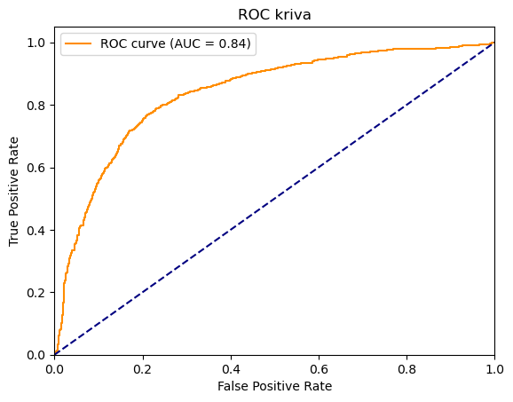

```python
import matplotlib.pyplot as plt
import sklearn

pred=[row[1] for row in training_prediction]

fpr, tpr, thresholds = sklearn.metrics.roc_curve(Y_prediction, pred)
roc_auc = sklearn.metrics.auc(fpr, tpr)

plt.plot(fpr, tpr, color = 'darkorange', label = 'ROC curve (AUC = %0.2f)' % roc_auc)
plt.plot([0, 1], [0, 1], color = 'navy', linestyle = '--')
plt.xlim([0.0, 1.0])
plt.ylim([0.0, 1.05])
plt.xlabel('False Positive Rate')
plt.ylabel('True Positive Rate')
plt.title('ROC kriva')
plt.legend(loc = "upper left")
plt.show()
```

U našem slučaju grafik deluje povoljno, a AUC iznosi 0.84 što je vrlo dobro. Naravno, ovu vrednost računamo na test skupu.

Takođe, AUC je odlična mera za poredjenje 2 klasifikatora. Veća površina ukazuje na bolju prediktivnu moć modela.

### Moguća unapređenja

Ovaj model je daleko od kvalitetnog, ali svakako je unapređenje u odnosu na početnih 64%. Smatramo da ovaj projekat ima dosta mesta za napredak, pa ćemo navesti neka mesta na kojima bismo to mogli da izvedemo:

- Iskoristiti i ostale informacije koje su nam dostupne. Na primer, nigde nismo koristili rundu u kojoj se igra meč, pa ako je u pitanju finale, možemo da posmatramo kakav učinak igrač ima u tom nivou takmičenja (slobodnije rečeno, posmatramo kako se igrač nosi sa pritiskom)
- Dodati još prediktora. Jedan od primera jeste učinak protiv igrača koji igraju levom, odnosno desnom rukom;
- Isprobati neki napredniji model od logističke regresije.
- Napraviti grafički interfejs: tada bi korisnici mogli da selektuju koja dva igrača igraju i da im se prikažu verovatnoće pobede za obojicu;
- Povezati bazu sa programom, tako da se baza u realnom vremenu ažurira (npr. jednom nedeljno);